# Predicting Heart Disease using R

Bree McLennan

20 January 2019

# Purpose and objective of this project

The purpose of this project is to demonstrate the application of a practical and useful data science project workflow. This workflow will be applied to a supervised machine learning problem (binary classification).

This project will be segmented into three parts:

- Part 1: Learning about the problem and the data we have.
- Part 2: The initial iteration of modelling experimentation.
- Part 3: Refined iteration of modelling: XGBoost.

This project will be written in R, with the [Github repository link here.](https://github.com/breemclennan/predicting_heart_disease)

# Part 1: Learning about the problem and the data we have

## Learning about the problem

Initial questions to ask before starting a new project

**Q1: What is the problem we are attempting to solve?**

Real world problem: Given a set of medical patient test results, predict the likelihood the patient has heart disease. Data Science problem translation: Supervised machine learning, binary classification.

References - drivendata - UCI source data

**Q2: Who owns the problem?**

**Q3: Why does a solution matter? What value will a solution bring?** - time, value, cost, implementability, ease of use, maintainability

**Q4: Human versus Machine: In this problem, what success rate does a human have in predicting outcomes?** - what performance level would the ML solution need to achieve in order to be acceptable and useful?

**Q5: What reference material exists to support our attempt?**

**Q6: Where is the data and how do we access it?**

[The source data is available from this link here.](https://archive.ics.uci.edu/ml/datasets/heart+Disease)

**Q7: What is the target variable and how was it created?** what does it represent?

**Q8: What data features do we have to work with?** what is in the data dictionary supplied with the dataset?

## The data we have

### Initial data triage

1. Read in the dataset and apply variable labels

```r
# Read in CSV
# TRAINING SETS #
raw.train_labels <- read.csv(F("/Data/train_labels.csv"), stringsAsFactors = FALSE)
raw.train_values <- read.csv(F("/Data/train_values.csv"), stringsAsFactors = FALSE)

# TESTING SETS
raw.test_values <- read.csv(F("/Data/test_values.csv"), stringsAsFactors = FALSE)


# Attach training values to training labels by primary key "patient_id"
wrk.train <- list(raw.train_labels, raw.train_values) %>%
  reduce(left_join, by = c("patient_id" = "patient_id")) %>%
  mutate(CATDataSetOrigin = "Training")

# setup the test dataset ready to append by row, to the training set.
wrk.test <- raw.test_values %>%
  mutate(CATDataSetOrigin =  "Testing") %>%
  mutate(heart_disease_present = NA) # create the column for target but keep NULL.
```

2. Combine the test and train datasets

```r
# Append all above raw datasets together:
# WARNING: columns are different between datasets because test doesn't have a target variable.
# Using rbind + FILL option
wrk.combined <- rbind(setDT(wrk.train), setDT(wrk.test), fill = TRUE)
```

3. Perform an initial assessment on the raw data

3.1. Dimensions, structure

```r
# Dimensions of the dataset
# We can get a quick idea of how many instances (rows) and how many attributes (columns) the data contains with the dim function.
dim(wrk.combined)
```

```
## [1] 270  16
```

3.2. Data Types

```r
# Types of attributes
# It is a good idea to get an idea of the types of the attributes.
# They could be doubles, integers, strings, factors and other types.
# Knowing the types is important as it will give you an idea
# of how to better summarize the data you have and the types of transforms you might need to use to prepare the data before you model it.
# list types for each attribute
sapply(wrk.combined, class)
```

```
##                           patient_id                heart_disease_present
##                          "character"                            "integer"
##    slope_of_peak_exercise_st_segment                                 thal
##                            "integer"                          "character"
##               resting_blood_pressure                      chest_pain_type
##                            "integer"                            "integer"
##                    num_major_vessels fasting_blood_sugar_gt_120_mg_per_dl
##                            "integer"                            "integer"
##                  resting_ekg_results          serum_cholesterol_mg_per_dl
##                            "integer"                            "integer"
##             oldpeak_eq_st_depression                                  sex
##                            "numeric"                            "integer"
##                                  age              max_heart_rate_achieved
##                            "integer"                            "integer"
##              exercise_induced_angina                     CATDataSetOrigin
##                            "integer"                          "character"
```

3.3. Summary

```r
# Peek at the data itself

datatable(head(wrk.combined), class = "cell-border stripe", filter = 'top', caption = 'Brief view of the data', rowname = FALSE, options = list(autoWidth = TRUE, searching = TRUE, pageLength = 5))
```

| patient_id | heart_disease_present | slope_of_peak_exercise_st_segment | thal | resting_blood_pressure | chest_pain_type | num_major_vessels | fasting_blood_sugar_gt_120_mg_per_dl | resting_ekg_results | serum_cholesterol_mg_per_dl | oldpeak_eq_st_depression | sex | age | max_heart_rate_achieved | exercise_induced_angina | CATDataSetOrigin |
| --- | --- | --- | --- | --- | --- | --- | --- | --- | --- | --- | --- | --- | --- | --- | --- |
| 0z64un | 0 | 1 | normal | 128 | 2 | 0 | 0 | 2 | 308 | 0 | 1 | 45 | 170 | 0 | Training |
| ryoo3j | 0 | 2 | normal | 110 | 3 | 0 | 0 | 0 | 214 | 1.6 | 0 | 54 | 158 | 0 | Training |
| yt1s1x | 1 | 1 | normal | 125 | 4 | 3 | 0 | 2 | 304 | 0 | 1 | 77 | 162 | 1 | Training |
| l2xjde | 1 | 1 | reversible_defect | 152 | 4 | 0 | 0 | 0 | 223 | 0 | 1 | 40 | 181 | 0 | Training |
| oyt4ek | 0 | 3 | reversible_defect | 178 | 1 | 0 | 0 | 2 | 270 | 4.2 | 1 | 59 | 145 | 0 | Training |
| ldukkw | 0 | 1 | normal | 130 | 3 | 0 | 0 | 0 | 180 | 0 | 1 | 42 | 150 | 0 | Training |

```r
mlr::summarizeColumns(wrk.combined) %>%
  kable("html", escape = FALSE, align = "c", caption = "Summarised Dataset Variables") %>%
  kable_styling(bootstrap_options =
                  c("striped", "condensed", "bordered"), full_width = FALSE)
```

| name | type | na | mean | disp | median | mad | min | max | nlevs |
| --- | --- | --- | --- | --- | --- | --- | --- | --- | --- |
| patient_id | character | 0 | NA | 0.9962963 | NA | NA | 1 | 1.0 | 270 |
| heart_disease_present | integer | 90 | 0.4444444 | 0.4982901 | 0.0 | 0.00000 | 0 | 1.0 | 0 |
| slope_of_peak_exercise_st_segment | integer | 0 | 1.5851852 | 0.6143898 | 2.0 | 1.48260 | 1 | 3.0 | 0 |
| thal | character | 0 | NA | 0.4370370 | NA | NA | 14 | 152.0 | 3 |
| resting_blood_pressure | integer | 0 | 131.3444444 | 17.8616083 | 130.0 | 14.82600 | 94 | 200.0 | 0 |
| chest_pain_type | integer | 0 | 3.1740741 | 0.9500900 | 3.0 | 1.48260 | 1 | 4.0 | 0 |
| num_major_vessels | integer | 0 | 0.6703704 | 0.9438964 | 0.0 | 0.00000 | 0 | 3.0 | 0 |
| fasting_blood_sugar_gt_120_mg_per_dl | integer | 0 | 0.1481481 | 0.3559065 | 0.0 | 0.00000 | 0 | 1.0 | 0 |
| resting_ekg_results | integer | 0 | 1.0222222 | 0.9978912 | 2.0 | 0.00000 | 0 | 2.0 | 0 |
| serum_cholesterol_mg_per_dl | integer | 0 | 249.6592593 | 51.6862371 | 245.0 | 48.18450 | 126 | 564.0 | 0 |
| oldpeak_eq_st_depression | numeric | 0 | 1.0500000 | 1.1452098 | 0.8 | 1.18608 | 0 | 6.2 | 0 |
| sex | integer | 0 | 0.6777778 | 0.4681954 | 1.0 | 0.00000 | 0 | 1.0 | 0 |
| age | integer | 0 | 54.4333333 | 9.1090665 | 55.0 | 10.37820 | 29 | 77.0 | 0 |
| max_heart_rate_achieved | integer | 0 | 149.6777778 | 23.1657168 | 153.5 | 22.98030 | 71 | 202.0 | 0 |
| exercise_induced_angina | integer | 0 | 0.3296296 | 0.4709516 | 0.0 | 0.00000 | 0 | 1.0 | 0 |
| CATDataSetOrigin | character | 0 | NA | 0.3333333 | NA | NA | 90 | 180.0 | 2 |

3.4. Identify potential transformations (recoding, renaming, simplification, centre, scale, normalise)

```r
  # TODO - list of variables to rename, list for recoding, list for numerical transformation
  # sample code for log transformations / reversibility
```

3.5. Identify potential for feature engineering options in later iterations

```r
 # TODO - brainstorming ideas for feature engineering. pros/cons
```

### Preparing the data for modelling (general)

1. Performing variable transformations and useful re-names

```r
# We have some character and numeric fields which can be recoded as factors
# Potential feature selection for furture iterations:
# thal, chest_pain_type asymptomatic, ST depression significant

wrk.combined_datatypecleaned <- wrk.combined %>%
  # The original source of the dataset defined the thal variable as a numeric variable with 3 discrete values, 3,6 and 7.
  # Lets experiment with this original data variable definition
  mutate(NUMthal = case_when(thal == "normal" ~ 3,
                             thal == "reversible_defect" ~ 6,
                             thal == "fixed_defect" ~ 7 )) %>%
  mutate(CATsex = case_when(sex == 0 ~ "female",
                            sex == 1 ~ "male")) %>%
  # chest pain type character categorty values derived from original source dataset
  mutate(CATchest_pain_type = case_when(chest_pain_type == 1 ~ "typical_angina",
                                        chest_pain_type == 2 ~ "atypical_angina",
                                        chest_pain_type == 3 ~ "non-anginal_pain",
                                        chest_pain_type == 4 ~ "asymptomatic")) %>%
  # slope of peak exercise st segment character categorty values derived from original source dataset
  mutate(CATslope_of_peak_exercise_st_segment = case_when(slope_of_peak_exercise_st_segment == 1 ~ "upsloping",
                                                          slope_of_peak_exercise_st_segment == 2 ~ "flat",
                                                          slope_of_peak_exercise_st_segment == 3 ~ "downsloping")) %>%
  mutate(CATfasting_blood_sugar_gt_120_mg_per_dl = case_when(fasting_blood_sugar_gt_120_mg_per_dl == 0 ~ "no",
                                                             fasting_blood_sugar_gt_120_mg_per_dl == 1 ~ "yes")) %>%
  ## IMPORTANT NOTE ON EKG - VALUE 1 LINKED WITH ST elevation or depression greater than 0.05 mV. Value 2 uses Estes' criteria measurement.
  # resting ekg results character categorty values derived from original source dataset
  mutate(CATresting_ekg_results = case_when(resting_ekg_results == 0 ~ "normal",
                                            resting_ekg_results == 1 ~ "ST-T_wave_abnormality",
                                            resting_ekg_results == 2 ~ "likely_left_ventricular_hypertrophy" )) %>%
  mutate(CATexercise_induced_angina = case_when(exercise_induced_angina == 0 ~ "no",
                                                exercise_induced_angina == 1 ~ "yes")) %>%
  # ENGINEERED FEATURES FOR EXPERIMENTATION:
  # 1. Numeric - Max Heart Rate for Age group. The theoretical maximum heart rate the patient ought to be able to achieve for their age
  mutate(NUMMaxHeartRateForAge = round(206.9 - (0.67 * age)),digits = 0) %>%
  # 2. Factor - CATMaxHeartRateAchieved - the theoretical maximum heart rate for the patient relative to their max hr test score
  mutate(CATMaxHeartRateAchieved = ifelse(max_heart_rate_achieved < (206.9 - (0.67 * age)),"Below_MHR_ForAge",
                                          "AtorAbove_MHR_ForAge" )) %>%
  # 3. Factor - CATOldpeakSTDepression - group the test results into minor or significant deviations
  mutate(CATOldpeakSTDepression = ifelse(oldpeak_eq_st_depression <= 2.0, "minor_ST_depression",
                                         "significant_ST_depression" )) %>%
  # FINAL SELECTION - what features will we remove, with respect to model output features of importance?
  dplyr::select(-NUMthal,
         -sex,
         -chest_pain_type,
         -slope_of_peak_exercise_st_segment,
         -fasting_blood_sugar_gt_120_mg_per_dl,
         -resting_ekg_results,
         -exercise_induced_angina) %>%

  # Apply some more meaninful names to the variables. Prefix data types.
  dplyr::rename(TARGET_heart_disease_present   = heart_disease_present,
                CATthal                        = thal,
                NUMresting_blood_pressure      = resting_blood_pressure,
                NUMnum_major_vessels           = num_major_vessels,
                NUMserum_cholesterol_mg_per_dl = serum_cholesterol_mg_per_dl,
                NUMoldpeak_eq_st_depression    = oldpeak_eq_st_depression,
                NUMage                         = age,
                NUMmax_heart_rate_achieved     = max_heart_rate_achieved) %>%
  #Convert the integer/logical target variable to factor
  mutate_at(.vars = vars(starts_with("CAT"), "TARGET_heart_disease_present"), #more categorical fields can be added here to convert in bulk,
            .funs = funs(as.factor(.)))
```

2. Feature engineering and selection (later iterations)

```r
#### FEATURE SELECTION ##########
glimpse(wrk.combined_datatypecleaned)
```

```
## Observations: 270
## Variables: 20
## $ patient_id                              <chr> "0z64un", "ryoo3j", "y...
## $ TARGET_heart_disease_present            <fct> 0, 0, 1, 1, 0, 0, 1, 1...
## $ CATthal                                 <fct> normal, normal, normal...
## $ NUMresting_blood_pressure               <int> 128, 110, 125, 152, 17...
## $ NUMnum_major_vessels                    <int> 0, 0, 3, 0, 0, 0, 2, 1...
## $ NUMserum_cholesterol_mg_per_dl          <int> 308, 214, 304, 223, 27...
## $ NUMoldpeak_eq_st_depression             <dbl> 0.0, 1.6, 0.0, 0.0, 4....
## $ NUMage                                  <int> 45, 54, 77, 40, 59, 42...
## $ NUMmax_heart_rate_achieved              <int> 170, 158, 162, 181, 14...
## $ CATDataSetOrigin                        <fct> Training, Training, Tr...
## $ CATsex                                  <fct> male, female, male, ma...
## $ CATchest_pain_type                      <fct> atypical_angina, non-a...
## $ CATslope_of_peak_exercise_st_segment    <fct> upsloping, flat, upslo...
## $ CATfasting_blood_sugar_gt_120_mg_per_dl <fct> no, no, no, no, no, no...
## $ CATresting_ekg_results                  <fct> likely_left_ventricula...
## $ CATexercise_induced_angina              <fct> no, no, yes, no, no, n...
## $ NUMMaxHeartRateForAge                   <dbl> 177, 171, 155, 180, 16...
## $ digits                                  <dbl> 0, 0, 0, 0, 0, 0, 0, 0...
## $ CATMaxHeartRateAchieved                 <fct> Below_MHR_ForAge, Belo...
## $ CATOldpeakSTDepression                  <fct> minor_ST_depression, m...
```

```r
wrk.combined_datatypecleaned <- dplyr::select(wrk.combined_datatypecleaned, patient_id, TARGET_heart_disease_present, CATDataSetOrigin,
                                       CATthal,CATchest_pain_type,  NUMoldpeak_eq_st_depression, NUMnum_major_vessels,
                                       NUMMaxHeartRateForAge, NUMmax_heart_rate_achieved,
                                       CATsex, CATexercise_induced_angina, CATslope_of_peak_exercise_st_segment,
                                       NUMage)
features_selected = c("CATthal","CATchest_pain_type",  "NUMoldpeak_eq_st_depression", "NUMnum_major_vessels","NUMMaxHeartRateForAge", "NUMmax_heart_rate_achieved", "CATsex", "CATexercise_induced_angina", "CATslope_of_peak_exercise_st_segment","NUMage")
```

3. Converting character data types to factors

```r
# Make sure categoricals are factors
wrk.combined_datatypecleaned <- wrk.combined_datatypecleaned %>%
  mutate_at( #Convert the integer/logical target variable to factor
    .vars = vars(starts_with("CAT"),"TARGET_heart_disease_present"), #more categorical fields can be added here to convert in bulk,
    .funs = funs(as.factor(.))
  )
```

4. Dealing with missing data (options of default values, means and modes)

```r
 # TODO
```

5. Calculate near zero variance and zero variance

```r
# Find Zero Variance and Near Zero Variance columns and remove from combined set
nzv <- caret::nearZeroVar(wrk.combined_datatypecleaned, saveMetrics = TRUE)
cols_zeroVar <- rownames(nzv[which(nzv$zeroVar == TRUE), ])
cols_nearzeroVar <- rownames(nzv[which(nzv$nzv == TRUE), ])
`%ni%` <- Negate(`%in%`)
wrk.combined_datatypecleaned <- subset(wrk.combined_datatypecleaned, select = names(wrk.combined_datatypecleaned) %ni% cols_zeroVar)
```

### Visualising the data and determine modelling “fit for purpose”

```r
# Setup for visualisations
#We now have a basic idea about the data. We need to extend that with some visualizations.
#We are going to look at two types of plots:

# 1. Univariate plots to better understand each attribute.
# 2. Multivariate plots to better understand the relationships between attributes.
x <- dplyr::select(wrk.combined_datatypecleaned, -patient_id, -TARGET_heart_disease_present, -CATDataSetOrigin )
x_num <- dplyr::select(wrk.combined_datatypecleaned,(starts_with("NUM")))
x_cat <- dplyr::select(wrk.combined_datatypecleaned,(starts_with("CAT")),"TARGET_heart_disease_present",  -patient_id, -CATDataSetOrigin)
y <- dplyr::select(wrk.combined_datatypecleaned, TARGET_heart_disease_present)
```

1. Summary table with SkimR

```r
#fix_windows_histograms()

skimr::skim(wrk.combined_datatypecleaned) %>% kable()
```

[output not shown]

[output cut: 166 more lines]

[output not shown]

```r
#%>%
 # kable("html", escape = FALSE, align = "c", caption = "Summarised Dataset with Cleaned Variables") %>%
#  kable_styling(bootstrap_options = c("striped", "condensed", "bordered"), full_width = FALSE)
# sparkline graphs for numerics!
```

2. Distribution of the target class variable

```r
# Target class distribution
# take a look at the number of instances (rows) that belong to each class. We can view this as an absolute count and as a percentage.
# summarize the class distribution
percentage <- prop.table(table(wrk.combined_datatypecleaned$TARGET_heart_disease_present)) * 100
cbind(freq = table(wrk.combined_datatypecleaned$TARGET_heart_disease_present), percentage = percentage)
```

```
##   freq percentage
## 0  100   55.55556
## 1   80   44.44444
```

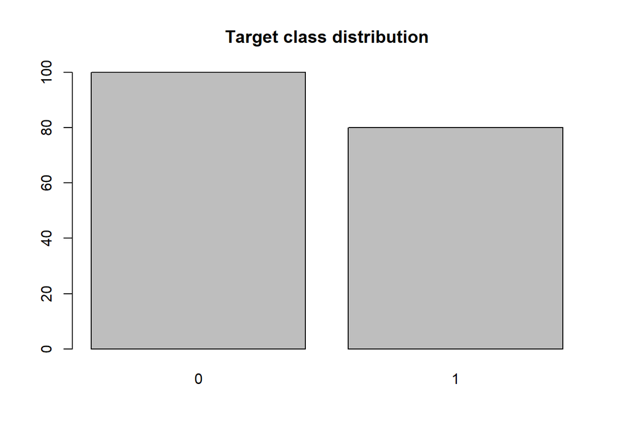

```r
# We can also create a barplot of
# the target class variable to get a graphical representation of the class distribution
# (generally uninteresting in this case because they are close to being balanced).
# barplot for class breakdown
plot(y, main = "Target class distribution")
```

3. Statistical summaries by target class

```r
# Statistical summaries
# Now finally, we can take a look at a summary of each attribute in relation to the target variable
mydata <- dplyr::group_by(wrk.combined_datatypecleaned, TARGET_heart_disease_present) %>%
  skimr::skim()

mydata %>% kable()
```

[output not shown]

[output cut: 465 more lines]

[output not shown]

```r
#("html", escape = FALSE, align = "c", caption = "Summary of each variable relative to target variable") %>%
#  kable_styling(bootstrap_options = c("striped", "condensed", "bordered"), full_width = FALSE)
```

4. Scatterplot matrices (numerics), featureplots (factors & categories) and density plots by target class

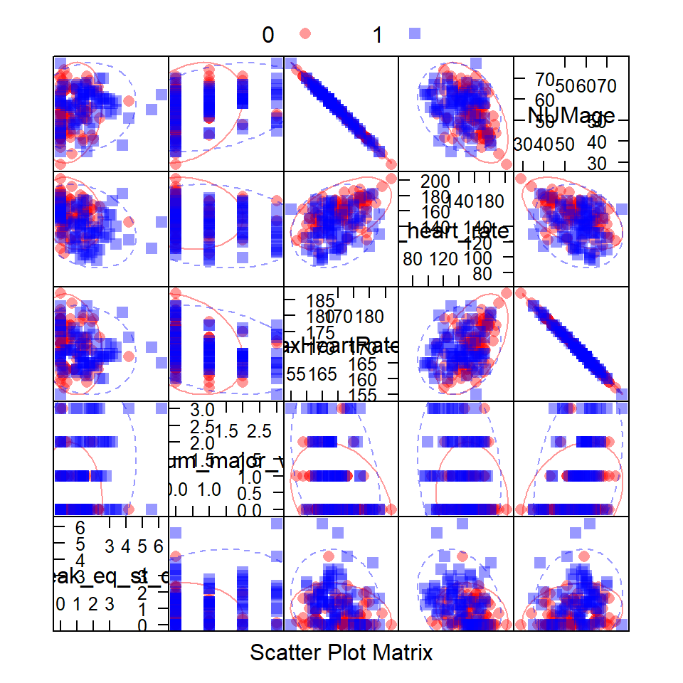

```r
# Multivariate plots
#Now we can look at the interactions between the variables.
#First let’s look at scatterplots of all pairs of attributes and color the points by class.
#In addition, because the scatterplots show that points for each class are generally separate,
#we can draw ellipses around them.

# scatterplot matrix with ellipses
AppliedPredictiveModeling::transparentTheme(trans = .4)
caret::featurePlot(x = x_num,
                   y = y$TARGET_heart_disease_present,
                   plot = "ellipse", #alt "pairs"
                   ## Add a key at the top (two levels)
                   auto.key = list(columns = 2))
```

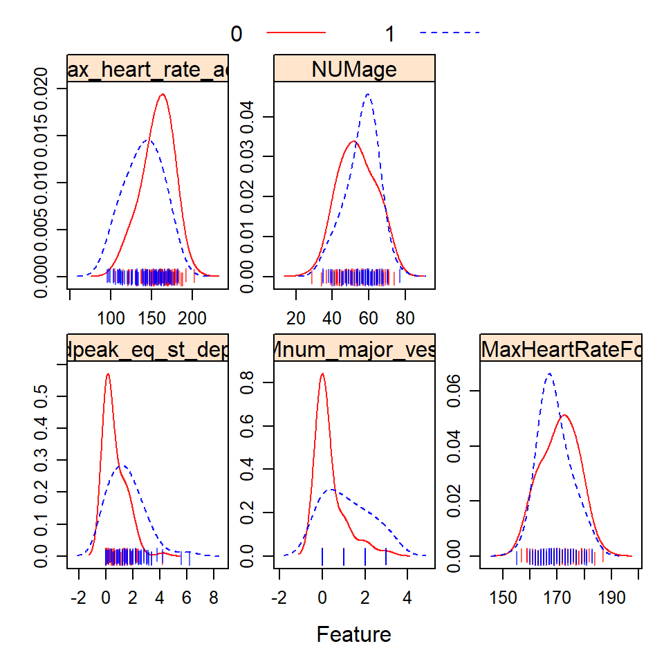

```r
# Overlayed density plots
AppliedPredictiveModeling::transparentTheme(trans = .9)
featurePlot(x = x_num,
            y = y$TARGET_heart_disease_present,
            plot = "density",
            ## Pass in options to xyplot() to
            ## make it prettier
            scales = list(x = list(relation="free"),
                          y = list(relation="free")),
            adjust = 1.5,
            pch = "|",
            layout = c(3, 2),
            auto.key = list(columns = 2))
```

```r
# Correlation plot (small number of original numeric vars):
cor(x_num) #%>% kable()
```

```
##                             NUMoldpeak_eq_st_depression
## NUMoldpeak_eq_st_depression                   1.0000000
## NUMnum_major_vessels                          0.2550055
## NUMMaxHeartRateForAge                        -0.1947955
## NUMmax_heart_rate_achieved                   -0.3490454
## NUMage                                        0.1942339
##                             NUMnum_major_vessels NUMMaxHeartRateForAge
## NUMoldpeak_eq_st_depression            0.2550055            -0.1947955
## NUMnum_major_vessels                   1.0000000            -0.3524218
## NUMMaxHeartRateForAge                 -0.3524218             1.0000000
## NUMmax_heart_rate_achieved            -0.2653328             0.4029610
## NUMage                                 0.3560806            -0.9989773
##                             NUMmax_heart_rate_achieved     NUMage
## NUMoldpeak_eq_st_depression                 -0.3490454  0.1942339
## NUMnum_major_vessels                        -0.2653328  0.3560806
## NUMMaxHeartRateForAge                        0.4029610 -0.9989773
## NUMmax_heart_rate_achieved                   1.0000000 -0.4022154
## NUMage                                      -0.4022154  1.0000000
```

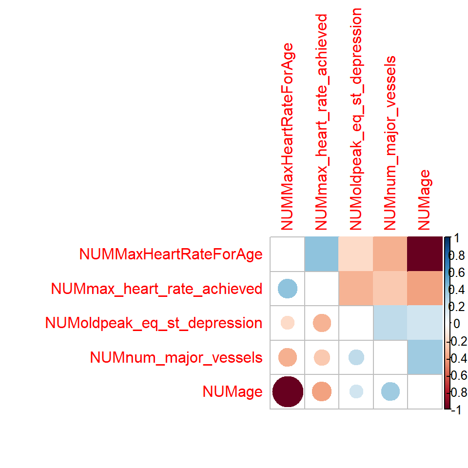

```r
  #kable("html", escape = FALSE, align = "c", caption = "Correlation of Numeric Variables") %>%
  #kable_styling(bootstrap_options = c("striped", "condensed", "bordered"), full_width = FALSE)
  # print correlation matrix results first, then visually plot.

corrplot::corrplot.mixed(cor(x_num), lower="circle", upper="color",
               tl.pos="lt", diag="n", order = "hclust", hclust.method="complete")
```

5. Box and whisker plots (numerics) by target class

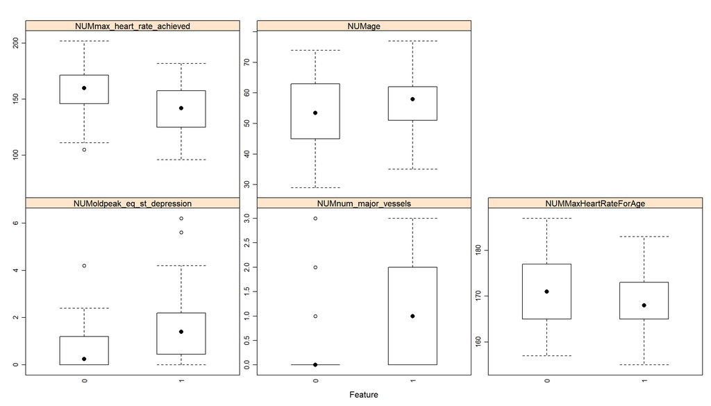

```r
# box and whisker plots for each attribute (numeric)
featurePlot(x = x_num,
            y = y$TARGET_heart_disease_present,
            plot = "box",
            ## Pass in options to bwplot()
            scales = list(y = list(relation="free"),
                          x = list(rot = 90)),
            layout = c(3,2 ),
            auto.key = list(columns = 2))
```

6. Grouped bar plots (factors & categories) by target class

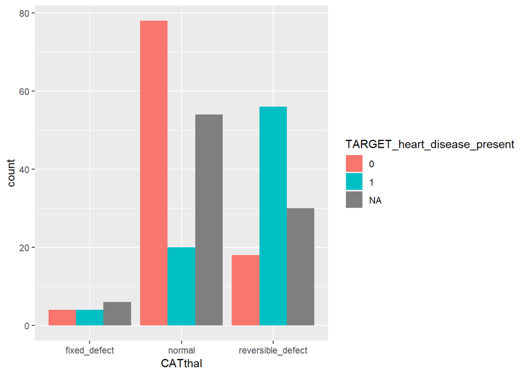

```r
# Categorical/Factor- grouped bar plots - checking frequency counts
ggplot(x_cat, aes(x=CATthal, fill=TARGET_heart_disease_present)) +
  geom_bar(position="dodge", stat="count")
```

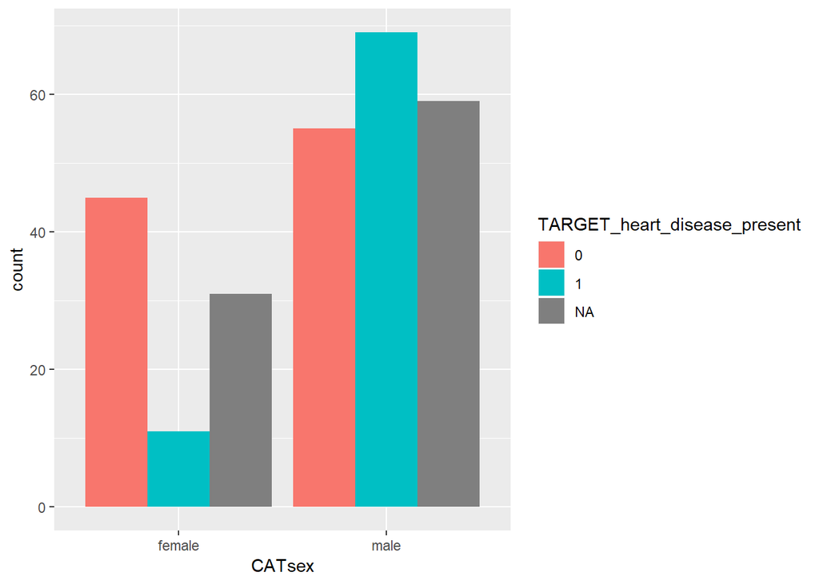

```r
ggplot(x_cat, aes(x=CATsex, fill=TARGET_heart_disease_present)) +
  geom_bar(position="dodge", stat="count")
```

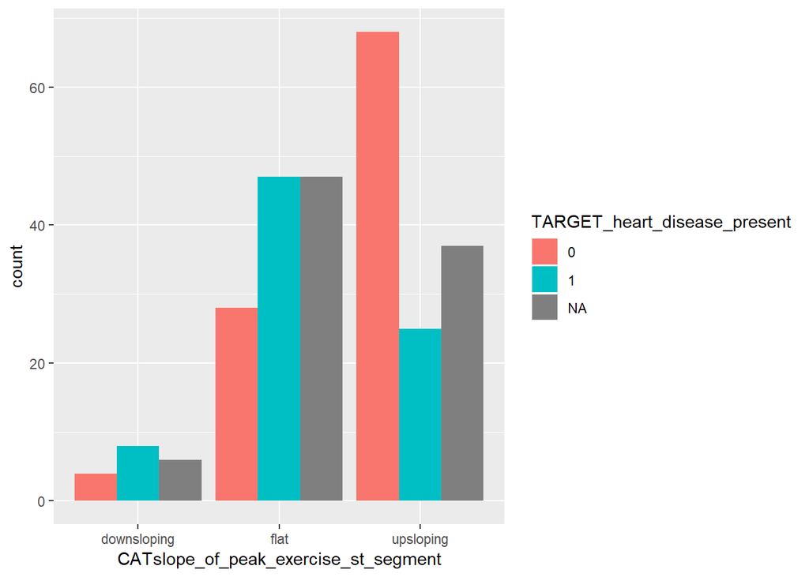

```r
ggplot(x_cat, aes(x=CATslope_of_peak_exercise_st_segment, fill=TARGET_heart_disease_present)) +
  geom_bar(position="dodge", stat="count")
```

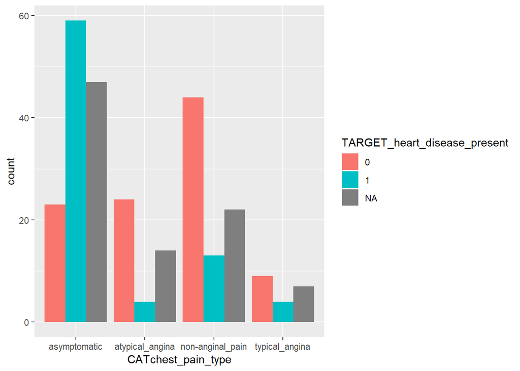

```r
ggplot(x_cat, aes(x=CATchest_pain_type, fill=TARGET_heart_disease_present)) +
  geom_bar(position="dodge", stat="count")
```

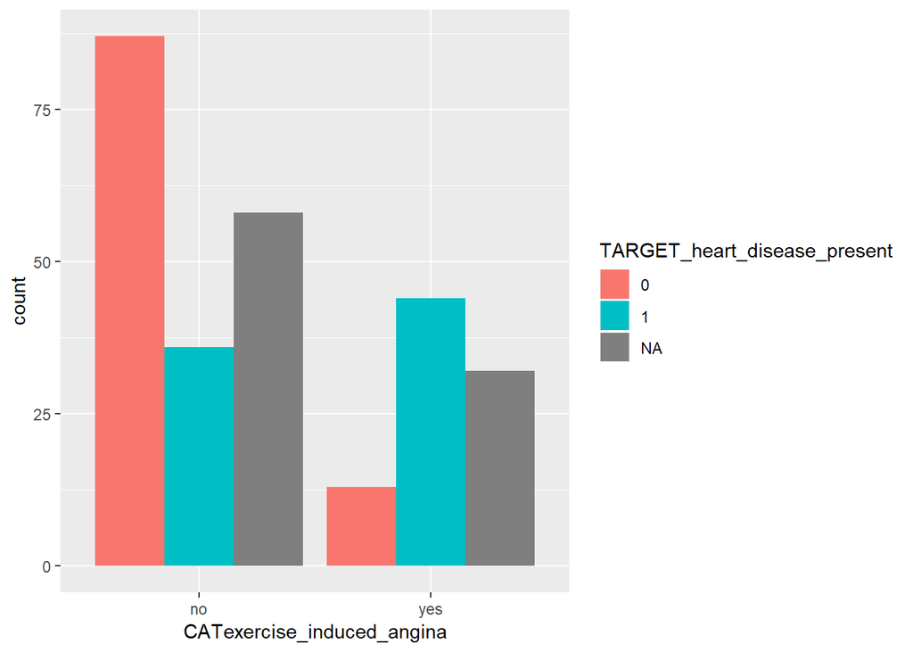

```r
ggplot(x_cat, aes(x=CATexercise_induced_angina, fill=TARGET_heart_disease_present)) +
  geom_bar(position="dodge", stat="count")
```

7. Custom function: Multi-plot mosaic plot (factors & categories) by target class

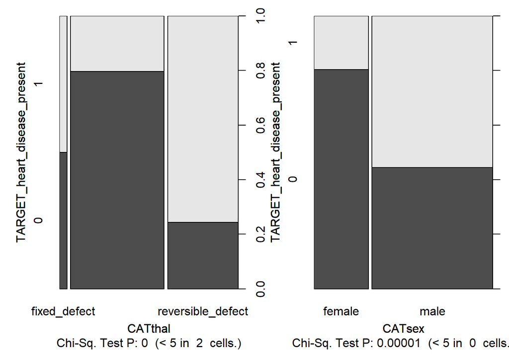

```r
# Create a MOSIAC PLOT OF CHAR/FACTOR VS TARGET
#See code 99_Functions
#plot.new()
#dev.off()
x_cat_p1 <- dplyr::select(x_cat, TARGET_heart_disease_present, CATthal, CATsex)
x_cat_p2 <- dplyr::select(x_cat, TARGET_heart_disease_present, CATslope_of_peak_exercise_st_segment)
x_cat_p3 <- dplyr::select(x_cat, TARGET_heart_disease_present, CATchest_pain_type)
x_cat_p4 <- dplyr::select(x_cat, TARGET_heart_disease_present, CATexercise_induced_angina)
multiplot(x_cat_p1, 'TARGET_heart_disease_present')
```

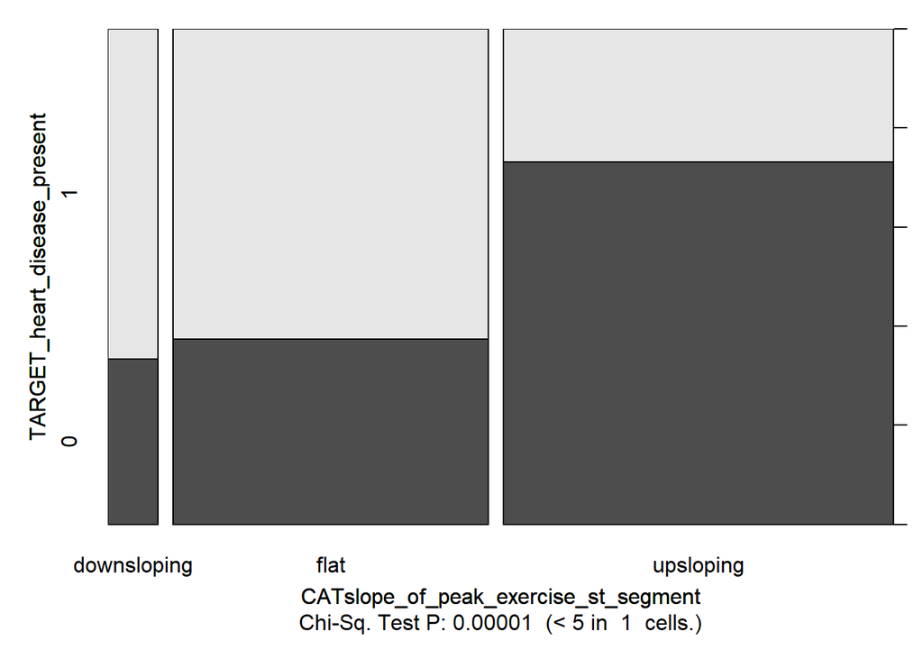

```r
multiplot(x_cat_p2, 'TARGET_heart_disease_present')
```

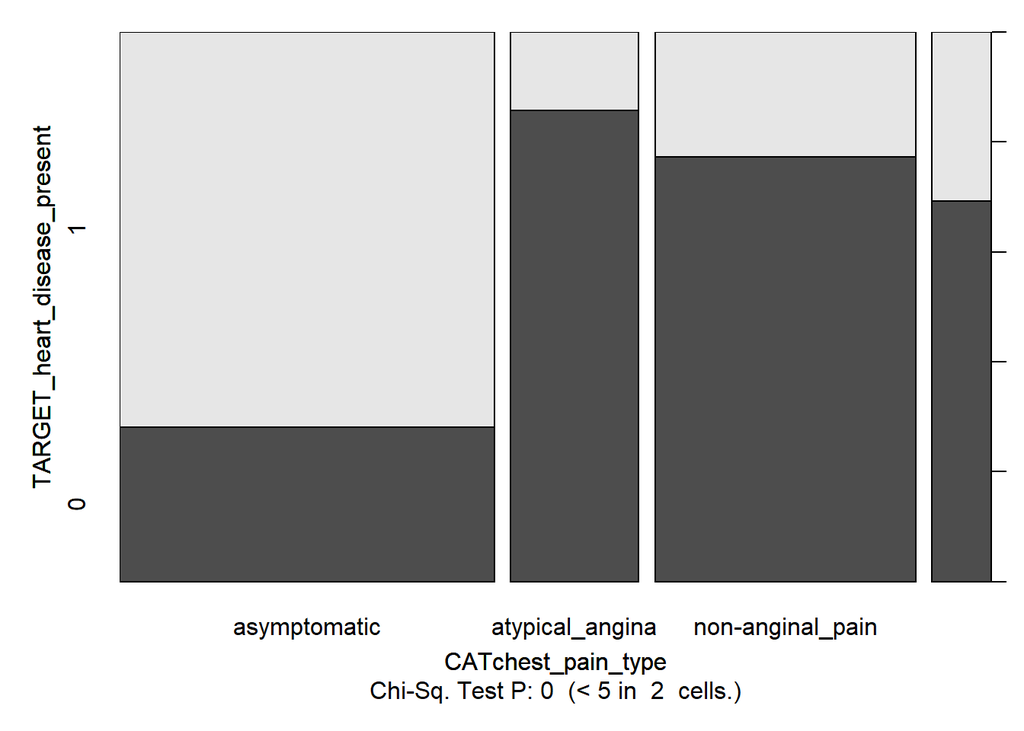

```r
multiplot(x_cat_p3, 'TARGET_heart_disease_present')
```